# matplotlib.pyplot.figure

**matplotlib.pyplot.figure(*num=None*, *figsize=None*, *dpi=None*, *, *facecolor=None*, *edgecolor=None*, *frameon=True*, *FigureClass=<class 'matplotlib.figure.Figure'>*, *clear=False*, **kwargs)[[source]](https://github.com/matplotlib/matplotlib/blob/v3.9.2/lib/matplotlib/pyplot.py#L870-L1056)**

Create a new figure, or activate an existing figure.

**Parameters:**

**num**int or str or `Figure` or `SubFigure`, optional**

A unique identifier for the figure.

If a figure with that identifier already exists, this figure is made active and returned. An integer refers to the `Figure.number` attribute, a string refers to the figure label.

If there is no figure with the identifier or *num* is not given, a new figure is created, made active and returned. If *num* is an int, it will be used for the `Figure.number` attribute, otherwise, an auto-generated integer value is used (starting at 1 and incremented for each new figure). If *num* is a string, the figure label and the window title is set to this value. If num is a `SubFigure`, its parent `Figure` is activated.

**figsize**(float, float), default: `rcParams["figure.figsize"]` (default: `[6.4, 4.8]`)**

Width, height in inches.

**dpi**float, default: `rcParams["figure.dpi"]` (default: `100.0`)**

The resolution of the figure in dots-per-inch.

**facecolor**[color](https://matplotlib.org/stable/users/explain/colors/colors.html#colors-def), default: `rcParams["figure.facecolor"]` (default: `'white'`)**

The background color.

**edgecolor**[color](https://matplotlib.org/stable/users/explain/colors/colors.html#colors-def), default: `rcParams["figure.edgecolor"]` (default: `'white'`)**

The border color.

**frameon**bool, default: True**

If False, suppress drawing the figure frame.

**FigureClass**subclass of `Figure`**

If set, an instance of this subclass will be created, rather than a plain `Figure`.

**clear**bool, default: False**

If True and the figure already exists, then it is cleared.

**layout**{'constrained', 'compressed', 'tight', 'none', `LayoutEngine`, None}, default: None**

The layout mechanism for positioning of plot elements to avoid overlapping Axes decorations (labels, ticks, etc). Note that layout managers can measurably slow down figure display.

- 'constrained': The constrained layout solver adjusts Axes sizes to avoid overlapping Axes decorations. Can handle complex plot layouts and colorbars, and is thus recommended.

  See [Constrained layout guide](https://matplotlib.org/stable/users/explain/axes/constrainedlayout_guide.html#constrainedlayout-guide) for examples.
- 'compressed': uses the same algorithm as 'constrained', but removes extra space between fixed-aspect-ratio Axes. Best for simple grids of Axes.
- 'tight': Use the tight layout mechanism. This is a relatively simple algorithm that adjusts the subplot parameters so that decorations do not overlap. See `Figure.set_tight_layout` for further details.
- 'none': Do not use a layout engine.
- A `LayoutEngine` instance. Builtin layout classes are `ConstrainedLayoutEngine` and `TightLayoutEngine`, more easily accessible by 'constrained' and 'tight'. Passing an instance allows third parties to provide their own layout engine.

If not given, fall back to using the parameters *tight_layout* and *constrained_layout*, including their config defaults `rcParams["figure.autolayout"]` (default: `False`) and `rcParams["figure.constrained_layout.use"]` (default: `False`).

**kwargs**

Additional keyword arguments are passed to the `Figure` constructor.

**Returns:**

**`Figure`**

#### Notes

A newly created figure is passed to the `new_manager` method or the `new_figure_manager` function provided by the current backend, which install a canvas and a manager on the figure.

Once this is done, `rcParams["figure.hooks"]` (default: `[]`) are called, one at a time, on the figure; these hooks allow arbitrary customization of the figure (e.g., attaching callbacks) or of associated elements (e.g., modifying the toolbar). See [mplcvd -- an example of figure hook](https://matplotlib.org/stable/gallery/user_interfaces/mplcvd.html) for an example of toolbar customization.

If you are creating many figures, make sure you explicitly call `pyplot.close` on the figures you are not using, because this will enable pyplot to properly clean up the memory.

`rcParams` defines the default values, which can be modified in the matplotlibrc file.

## Examples using `matplotlib.pyplot.figure`

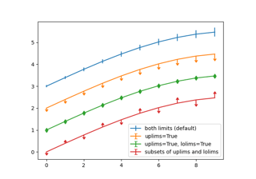

[Errorbar limit selection](https://matplotlib.org/stable/gallery/lines_bars_and_markers/errorbar_limits_simple.html#sphx-glr-gallery-lines-bars-and-markers-errorbar-limits-simple-py)

Errorbar limit selection

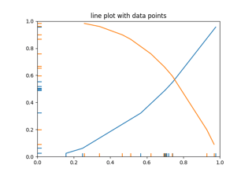

[EventCollection Demo](https://matplotlib.org/stable/gallery/lines_bars_and_markers/eventcollection_demo.html#sphx-glr-gallery-lines-bars-and-markers-eventcollection-demo-py)

EventCollection Demo

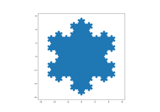

[Filled polygon](https://matplotlib.org/stable/gallery/lines_bars_and_markers/fill.html#sphx-glr-gallery-lines-bars-and-markers-fill-py)

Filled polygon

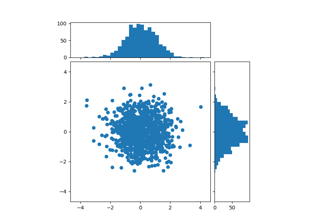

[Scatter plot with histograms](https://matplotlib.org/stable/gallery/lines_bars_and_markers/scatter_hist.html#sphx-glr-gallery-lines-bars-and-markers-scatter-hist-py)

Scatter plot with histograms

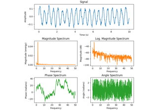

[Spectrum representations](https://matplotlib.org/stable/gallery/lines_bars_and_markers/spectrum_demo.html#sphx-glr-gallery-lines-bars-and-markers-spectrum-demo-py)

Spectrum representations

[figure not shown]

[Barcode](https://matplotlib.org/stable/gallery/images_contours_and_fields/barcode_demo.html#sphx-glr-gallery-images-contours-and-fields-barcode-demo-py)

Barcode

[figure not shown]

[Figimage Demo](https://matplotlib.org/stable/gallery/images_contours_and_fields/figimage_demo.html#sphx-glr-gallery-images-contours-and-fields-figimage-demo-py)

Figimage Demo

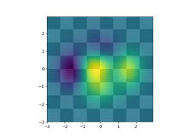

[Layer Images](https://matplotlib.org/stable/gallery/images_contours_and_fields/layer_images.html#sphx-glr-gallery-images-contours-and-fields-layer-images-py)

Layer Images

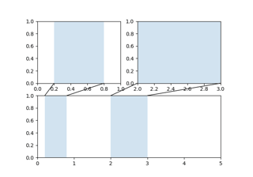

[Axes Zoom Effect](https://matplotlib.org/stable/gallery/subplots_axes_and_figures/axes_zoom_effect.html#sphx-glr-gallery-subplots-axes-and-figures-axes-zoom-effect-py)

Axes Zoom Effect

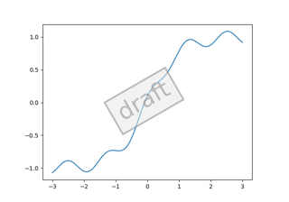

[Custom Figure subclasses](https://matplotlib.org/stable/gallery/subplots_axes_and_figures/custom_figure_class.html#sphx-glr-gallery-subplots-axes-and-figures-custom-figure-class-py)

Custom Figure subclasses

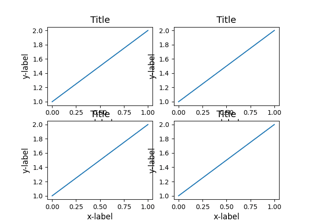

[Resizing Axes with constrained layout](https://matplotlib.org/stable/gallery/subplots_axes_and_figures/demo_constrained_layout.html#sphx-glr-gallery-subplots-axes-and-figures-demo-constrained-layout-py)

Resizing Axes with constrained layout

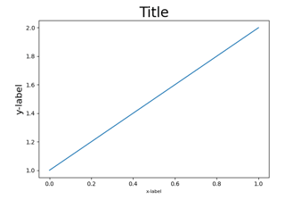

[Resizing Axes with tight layout](https://matplotlib.org/stable/gallery/subplots_axes_and_figures/demo_tight_layout.html#sphx-glr-gallery-subplots-axes-and-figures-demo-tight-layout-py)

Resizing Axes with tight layout

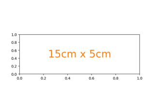

[Figure size in different units](https://matplotlib.org/stable/gallery/subplots_axes_and_figures/figure_size_units.html#sphx-glr-gallery-subplots-axes-and-figures-figure-size-units-py)

Figure size in different units

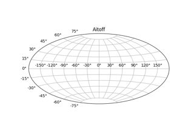

[Geographic Projections](https://matplotlib.org/stable/gallery/subplots_axes_and_figures/geo_demo.html#sphx-glr-gallery-subplots-axes-and-figures-geo-demo-py)

Geographic Projections

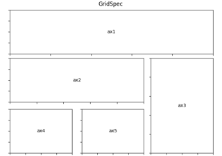

[Using Gridspec to make multi-column/row subplot layouts](https://matplotlib.org/stable/gallery/subplots_axes_and_figures/gridspec_multicolumn.html#sphx-glr-gallery-subplots-axes-and-figures-gridspec-multicolumn-py)

Using Gridspec to make multi-column/row subplot layouts

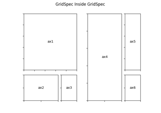

[Nested Gridspecs](https://matplotlib.org/stable/gallery/subplots_axes_and_figures/gridspec_nested.html#sphx-glr-gallery-subplots-axes-and-figures-gridspec-nested-py)

Nested Gridspecs

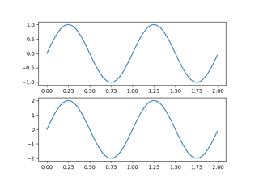

[Managing multiple figures in pyplot](https://matplotlib.org/stable/gallery/subplots_axes_and_figures/multiple_figs_demo.html#sphx-glr-gallery-subplots-axes-and-figures-multiple-figs-demo-py)

Managing multiple figures in pyplot

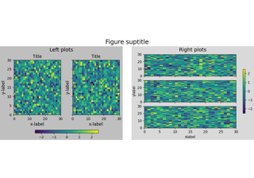

[Figure subfigures](https://matplotlib.org/stable/gallery/subplots_axes_and_figures/subfigures.html#sphx-glr-gallery-subplots-axes-and-figures-subfigures-py)

Figure subfigures

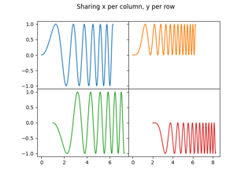

[Creating multiple subplots using plt.subplots](https://matplotlib.org/stable/gallery/subplots_axes_and_figures/subplots_demo.html#sphx-glr-gallery-subplots-axes-and-figures-subplots-demo-py)

Creating multiple subplots using plt.subplots

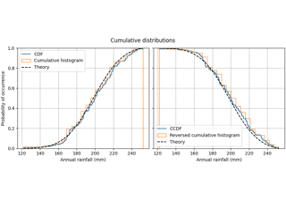

[Plotting cumulative distributions](https://matplotlib.org/stable/gallery/statistics/histogram_cumulative.html#sphx-glr-gallery-statistics-histogram-cumulative-py)

Plotting cumulative distributions

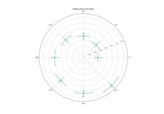

[Error bar rendering on polar axis](https://matplotlib.org/stable/gallery/pie_and_polar_charts/polar_error_caps.html#sphx-glr-gallery-pie-and-polar-charts-polar-error-caps-py)

Error bar rendering on polar axis

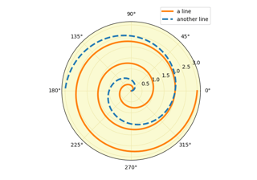

[Polar legend](https://matplotlib.org/stable/gallery/pie_and_polar_charts/polar_legend.html#sphx-glr-gallery-pie-and-polar-charts-polar-legend-py)

Polar legend

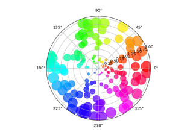

[Scatter plot on polar axis](https://matplotlib.org/stable/gallery/pie_and_polar_charts/polar_scatter.html#sphx-glr-gallery-pie-and-polar-charts-polar-scatter-py)

Scatter plot on polar axis

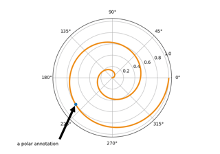

[Annotation Polar](https://matplotlib.org/stable/gallery/text_labels_and_annotations/annotation_polar.html#sphx-glr-gallery-text-labels-and-annotations-annotation-polar-py)

Annotation Polar

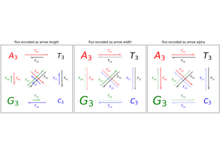

[Arrow Demo](https://matplotlib.org/stable/gallery/text_labels_and_annotations/arrow_demo.html#sphx-glr-gallery-text-labels-and-annotations-arrow-demo-py)

Arrow Demo

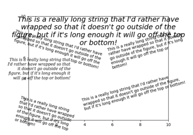

[Auto-wrapping text](https://matplotlib.org/stable/gallery/text_labels_and_annotations/autowrap.html#sphx-glr-gallery-text-labels-and-annotations-autowrap-py)

Auto-wrapping text

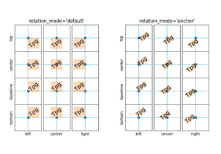

[Text Rotation Mode](https://matplotlib.org/stable/gallery/text_labels_and_annotations/demo_text_rotation_mode.html#sphx-glr-gallery-text-labels-and-annotations-demo-text-rotation-mode-py)

Text Rotation Mode

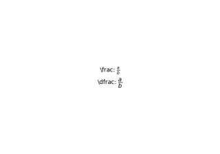

[The difference between \dfrac and \frac](https://matplotlib.org/stable/gallery/text_labels_and_annotations/dfrac_demo.html#sphx-glr-gallery-text-labels-and-annotations-dfrac-demo-py)

The difference between \dfrac and \frac

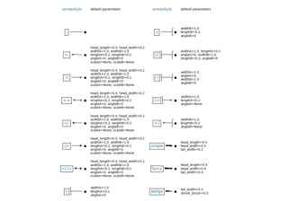

[Annotation arrow style reference](https://matplotlib.org/stable/gallery/text_labels_and_annotations/fancyarrow_demo.html#sphx-glr-gallery-text-labels-and-annotations-fancyarrow-demo-py)

Annotation arrow style reference

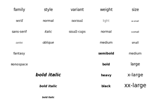

[Fonts demo (object-oriented style)](https://matplotlib.org/stable/gallery/text_labels_and_annotations/fonts_demo.html#sphx-glr-gallery-text-labels-and-annotations-fonts-demo-py)

Fonts demo (object-oriented style)

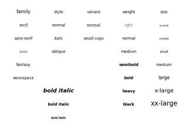

[Fonts demo (keyword arguments)](https://matplotlib.org/stable/gallery/text_labels_and_annotations/fonts_demo_kw.html#sphx-glr-gallery-text-labels-and-annotations-fonts-demo-kw-py)

Fonts demo (keyword arguments)

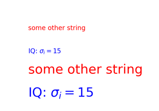

[Convert texts to images](https://matplotlib.org/stable/gallery/text_labels_and_annotations/mathtext_asarray.html#sphx-glr-gallery-text-labels-and-annotations-mathtext-asarray-py)

Convert texts to images

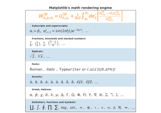

[Mathtext Examples](https://matplotlib.org/stable/gallery/text_labels_and_annotations/mathtext_examples.html#sphx-glr-gallery-text-labels-and-annotations-mathtext-examples-py)

Mathtext Examples

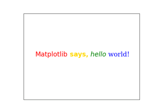

[Concatenating text objects with different properties](https://matplotlib.org/stable/gallery/text_labels_and_annotations/rainbow_text.html#sphx-glr-gallery-text-labels-and-annotations-rainbow-text-py)

Concatenating text objects with different properties

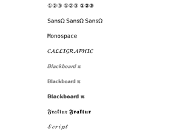

[STIX Fonts](https://matplotlib.org/stable/gallery/text_labels_and_annotations/stix_fonts_demo.html#sphx-glr-gallery-text-labels-and-annotations-stix-fonts-demo-py)

STIX Fonts

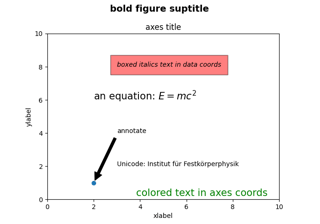

[Text Commands](https://matplotlib.org/stable/gallery/text_labels_and_annotations/text_commands.html#sphx-glr-gallery-text-labels-and-annotations-text-commands-py)

Text Commands

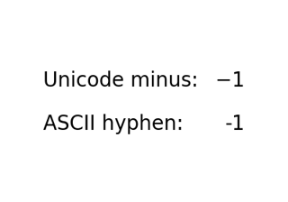

[Unicode minus](https://matplotlib.org/stable/gallery/text_labels_and_annotations/unicode_minus.html#sphx-glr-gallery-text-labels-and-annotations-unicode-minus-py)

Unicode minus

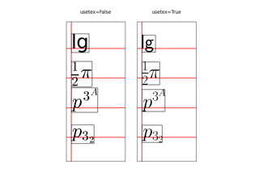

[Usetex Baseline Test](https://matplotlib.org/stable/gallery/text_labels_and_annotations/usetex_baseline_test.html#sphx-glr-gallery-text-labels-and-annotations-usetex-baseline-test-py)

Usetex Baseline Test

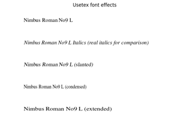

[Usetex Fonteffects](https://matplotlib.org/stable/gallery/text_labels_and_annotations/usetex_fonteffects.html#sphx-glr-gallery-text-labels-and-annotations-usetex-fonteffects-py)

Usetex Fonteffects

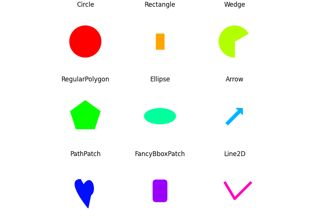

[Reference for Matplotlib artists](https://matplotlib.org/stable/gallery/shapes_and_collections/artist_reference.html#sphx-glr-gallery-shapes-and-collections-artist-reference-py)

Reference for Matplotlib artists

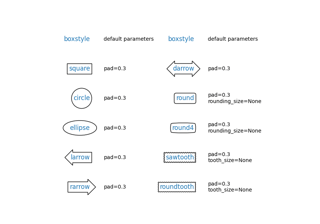

[Drawing fancy boxes](https://matplotlib.org/stable/gallery/shapes_and_collections/fancybox_demo.html#sphx-glr-gallery-shapes-and-collections-fancybox-demo-py)

Drawing fancy boxes

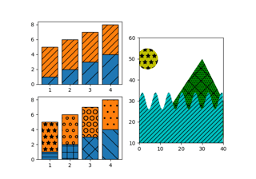

[Hatch demo](https://matplotlib.org/stable/gallery/shapes_and_collections/hatch_demo.html#sphx-glr-gallery-shapes-and-collections-hatch-demo-py)

Hatch demo

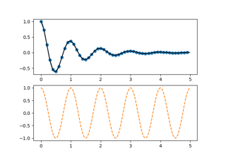

[Two subplots using pyplot](https://matplotlib.org/stable/gallery/pyplots/pyplot_two_subplots.html#sphx-glr-gallery-pyplots-pyplot-two-subplots-py)

Two subplots using pyplot

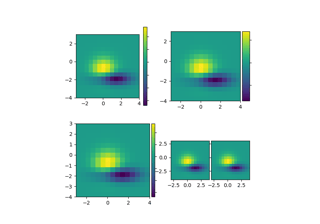

[Axes divider](https://matplotlib.org/stable/gallery/axes_grid1/demo_axes_divider.html#sphx-glr-gallery-axes-grid1-demo-axes-divider-py)

Axes divider

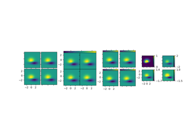

[Demo Axes Grid](https://matplotlib.org/stable/gallery/axes_grid1/demo_axes_grid.html#sphx-glr-gallery-axes-grid1-demo-axes-grid-py)

Demo Axes Grid

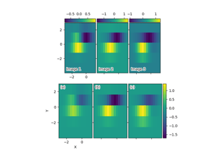

[Axes Grid2](https://matplotlib.org/stable/gallery/axes_grid1/demo_axes_grid2.html#sphx-glr-gallery-axes-grid1-demo-axes-grid2-py)